# Screening Task

Balaji Ganesh Anantharaman

8 June 2020

## Installing Required Packages

I used three external packages - data.table for reading in the data, ggplot2 and pheatmap for plotting different graphs

```r
install.packages("data.table", repo="https://ftp.osuosl.org/pub/cran/", quiet = TRUE)
```

```r
install.packages("ggplot2",repo="https://ftp.osuosl.org/pub/cran/", quiet = TRUE)
install.packages("pheatmap",repo="https://ftp.osuosl.org/pub/cran/", quiet = TRUE)
install.packages("pheatmap", repo="https://ftp.osuosl.org/pub/cran/", quiet = TRUE)
library(data.table)
library(pheatmap)
library(ggplot2)
library(knitr)
```

## Reading the Data

```r
basedir <- "C:/Users/Balaji Ganesh/OneDrive/Documents/Job Applications/Agendia/"
df <- fread(file.path(basedir, "Screening_Dataset.csv"))
knitr::kable(head(df), caption = "Dataset")
```

Dataset

| Var1 | Var2 | Var3 | Var4 | Var5 | Var6 | Var7 | Var8 | Var9 | Var10 |
| --- | --- | --- | --- | --- | --- | --- | --- | --- | --- |
| 0.1137034 | -0.0201424 | -0.1919814 | -0.1348785 | 0.5440537 | -0.1096932 | 0.8067396 | 0.1487233 | 0.2368245 | -0.0868084 |
| 0.6222994 | 0.7751048 | 0.2108050 | 0.7324555 | 0.6810616 | -0.5533725 | 0.9275814 | 0.5982776 | 0.8092179 | 0.6536935 |
| 0.6092747 | 0.6124718 | 0.0997665 | 0.4682870 | 0.4146512 | -0.7033634 | 0.4537964 | 0.5063539 | 0.4956360 | 0.0076742 |
| 0.6233794 | 0.3793364 | 0.3808844 | 0.7750012 | 0.3442873 | -0.6034256 | 0.4684725 | 0.8261421 | 0.7701830 | 0.0538772 |
| 0.8609154 | 0.8636818 | NA | 0.7260492 | 1.0896000 | -0.9072314 | 0.2676291 | 1.1496400 | 0.8276826 | 0.9470809 |
| 0.6403106 | 0.6360634 | 0.1255485 | 0.0904872 | 0.6994897 | -0.7161888 | 0.1318219 | 0.7373264 | 0.6455221 | 0.4422982 |

## Task One - Plot the relationship between the first two columns

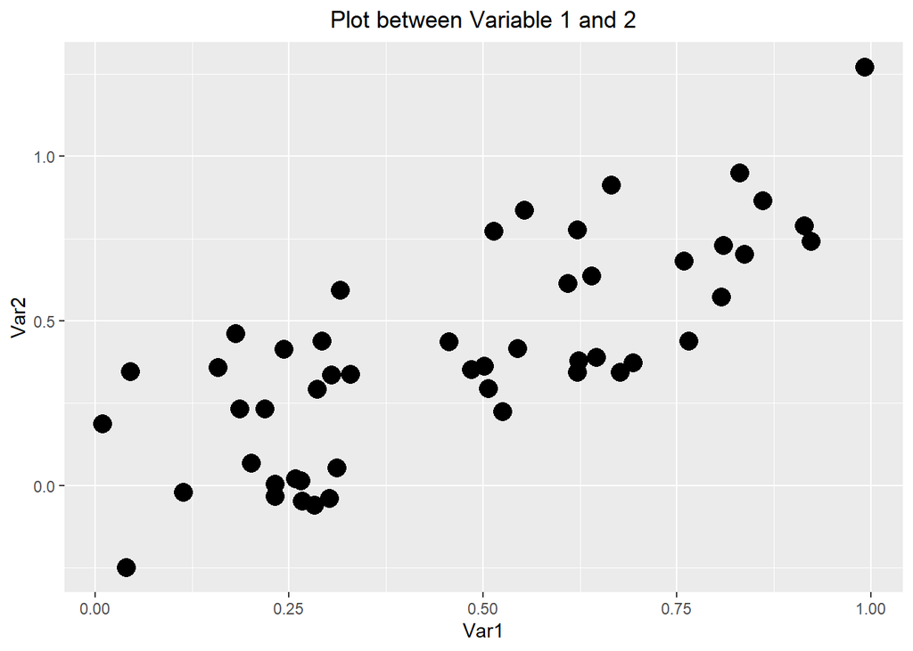

```r
one_two <- ggplot(data=df, mapping = aes(x=Var1, y=Var2)) + geom_point(aes(size = 2)) + labs(x = "Var1", y="Var2") + ggtitle("Plot between Variable 1 and 2") + theme(plot.title = element_text(hjust=0.5))
one_two + scale_size(guide='none')
```

## Task Two - Pearson Correlation between the first two columns

`"complete.obs"` - One way of working around Nan values. Corresponsing elements from both arrays are not used to calculate the correlation.

```r
correlation_1_2 <- cor(df$Var1, df$Var2, use="complete.obs")
cat(correlation_1_2)
```

```
## 0.7656714
```

## Task Three - Pearson Correlation between the second and third column

```r
correlation_2_3 <- cor(df$Var2, df$Var3, use="complete.obs")
cat(correlation_2_3)
```

```
## 0.4210432
```

## Task Four and Five - Which Columns are most related

Pearson Correlation is calculated between different pairs of columns. The values are stored in a symmetric matrix where A<sub>ij</sub> is the correlation between the i<sup>th</sup> and j<sup>th</sup> columns. A heatmap is plotted to represent this matrix - A Red Cell indicates positive correlation and a Blue Cell indicates negative correlation between the corresponding columns. Higher the intensity,stronger the correlation.

The first and sixth columns seem to be the most correlated.

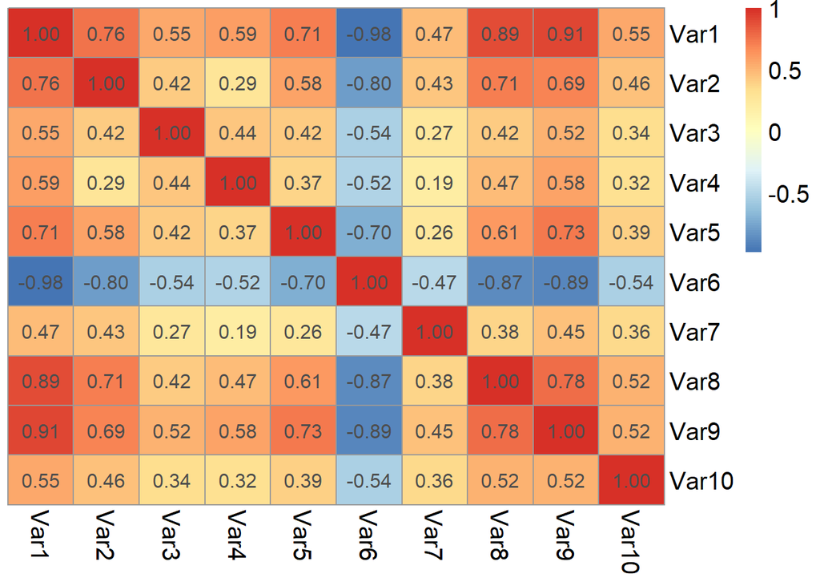

```r
cor_matrix <- cor(df, use="complete.obs")
pheatmap(cor_matrix, show_rownames = TRUE, show_colnames = TRUE, cluster_rows = FALSE, cluster_cols = FALSE, display_numbers = TRUE, fontsize = 15)
```

## Task Six - Equation of Best Fit

Linear regression between the two highly correlated columns would give us the required equation.

```r
lm_16 <- lm(Var1 ~ Var6, df)
```

We need to ensure that the major assumptions for linear regressions are met.

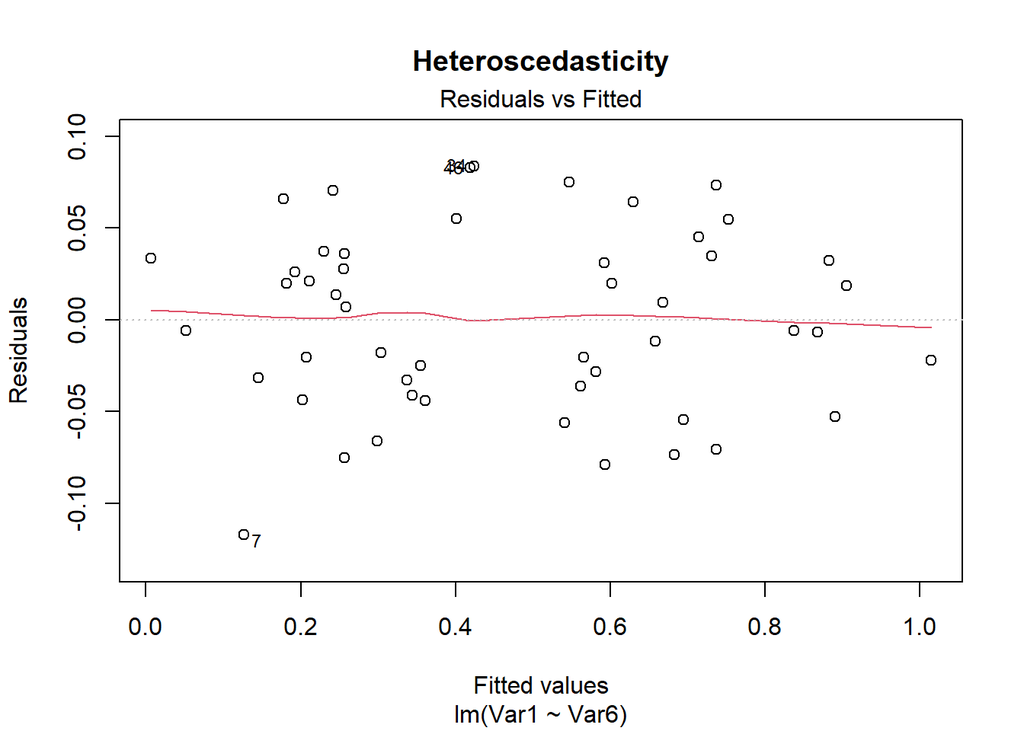

```r
plot(lm_16, which = 1, main = "Heteroscedasticity")
```

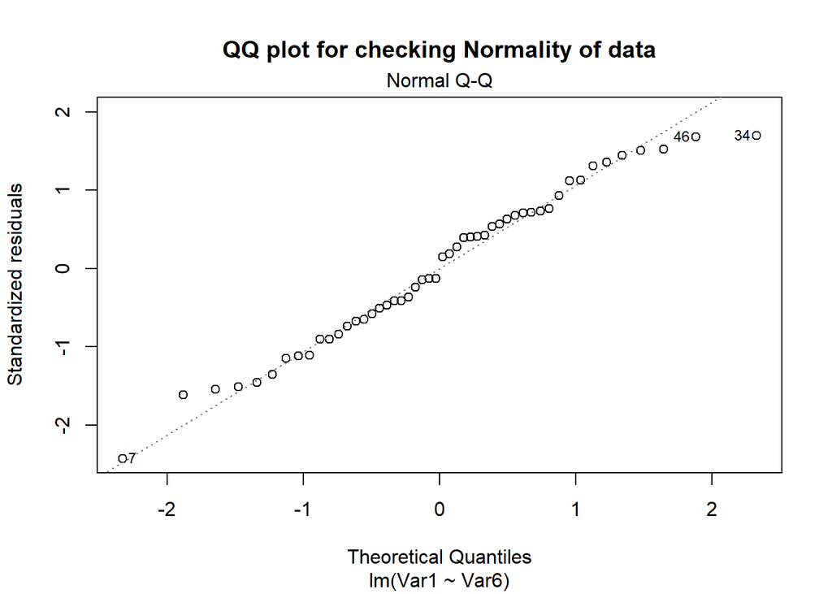

```r
plot(lm_16, which = 2, main = "QQ plot for checking Normality of data")
```

We see that the residuals do seem to have a constant variance. We also see from the qq-plot that the dependent variable follows the normal distribution.

## Task Seven - Plot of the equation

[figure not shown]

```r
equation <- paste0("Var6 = ", lm_16$coefficients[2],"*","Var1 ","+"," ",lm_16$coefficients[1])
one_six <- ggplot(data  = df, aes(Var1, Var6)) + geom_point(aes(size = 2)) + geom_smooth(method='lm') + annotate("text", x = 0.6, y = 0, label = equation) + annotate("text", x = 0.6, y = -0.05, label = paste0("Pearson_Correlation = ", cor_matrix[1,6]))
one_six + theme_bw() + theme(panel.grid.major = element_blank(), panel.grid.minor = element_blank(),plot.title = element_text(hjust = 0.5),text = element_text(size = 20)) +  scale_size(guide='none')+ggtitle("Plot between variable 1 and variable 6")
```